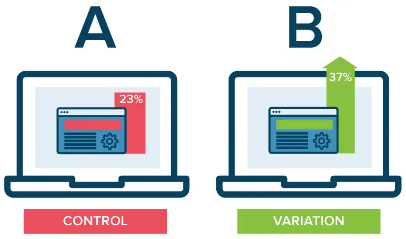

# Project: A/B testing of site versions

### Table of Contents:

- Introduction
- Part I - Exploratory Data Analysis(EDA) & Probability
- Part II - A/B Test
- Part III - Regression
- Conclusions

## Introduction

#### Ecommerce website analysis and A/B testing project. The new site was tested. The objectives of the project are:

- Evaluate the main indicators of conversion and income of the current and new version of the website;
- Compare site versions with each other. Is the new site for commerce better or not?
- Dive into additional metrics and assess their impact on conversions.

#### Importing libraries, uploading dataset

```python
import pandas as pd
import numpy as np
import matplotlib.pyplot as plt
import seaborn as sns
from datetime import date, datetime, timedelta as dt
%matplotlib inline
import pylab

from scipy import stats
from scipy.stats import shapiro
from scipy.stats import mannwhitneyu

# from scipy.stats import ttest_1samp, levene, ttest_ind, \
#     pearsonr, spearmanr, kendalltau, f_oneway, kruskal, normaltest

import statsmodels.stats.api as sms
import statsmodels.api as sm
from statsmodels.stats.proportion import proportions_ztest

from patsy import dmatrices
from statsmodels.stats.outliers_influence import variance_inflation_factor

import warnings
warnings.filterwarnings('ignore')
from tqdm import tqdm
# from sklearn.utils import resample
import random
random.seed(25)
```

```python
pd.set_option('display.max_columns', None)
pd.set_option('display.max_rows', 10)
pd.set_option('display.float_format', lambda x: '%.10f' % x)
```

```python
df = pd.read_csv('ab_test_site_01.2023.csv', index_col=0)
```

## Part I - Exploratory Data Analysis(EDA) & Probability

#### Procedure:

- Gathering data from the dataset and investigate it in an effort to understand more details about it.
- Performing a data assessment to identify any issues with data types, structure, or quality.
- Performing data cleaning by changing data types, replacing values, removing unnecessary data, and modifying the dataset for easier and faster analysis.

### `1.1` Description of the dataset

Below is the description of the data, there are a total of 7 columns and 287556 rows:

[output not shown]

```python
df.sample(5)
```

|  | user_id | timestamp | group | site | converted | country | revenue |
| --- | --- | --- | --- | --- | --- | --- | --- |
| 6209 | 711395 | 2023-01-12 00:48:40.290816 | variant | new | 0 | UK | 0.0000000000 |
| 213988 | 731259 | 2023-01-06 11:02:53.837083 | control | old | 0 | US | 0.0000000000 |
| 259947 | 714176 | 2023-01-08 19:34:58.110224 | variant | new | 0 | US | 0.0000000000 |
| 105380 | 857686 | 2023-01-12 17:15:34.405533 | variant | new | 0 | UK | 0.0000000000 |
| 172505 | 687975 | 2023-01-07 15:55:23.378043 | control | old | 0 | UK | 0.0000000000 |

```python
print('Shape of the training dataset:')
print('There are {} rows and {} columns in dataset.'.format(df.shape[0], df.shape[1]))
```

```
Shape of the training dataset:
There are 287556 rows and 7 columns in dataset.
```

```python
print('Number of unique users in the dataset is {}'.format(df.user_id.nunique()))
```

```
Number of unique users in the dataset is 283835
```

```python
df.info()
```

```
<class 'pandas.core.frame.DataFrame'>
Int64Index: 287556 entries, 0 to 287555
Data columns (total 7 columns):
 #   Column     Non-Null Count   Dtype
---  ------     --------------   -----
 0   user_id    287556 non-null  int64
 1   timestamp  287556 non-null  object
 2   group      287556 non-null  object
 3   site       287556 non-null  object
 4   converted  287556 non-null  int64
 5   country    287556 non-null  object
 6   revenue    287556 non-null  float64
dtypes: float64(1), int64(2), object(4)
memory usage: 17.6+ MB
```

#### Let's convert text data from timestamp to date and time.

```python
df.timestamp = pd.to_datetime(df.timestamp)
```

#### Let's display the minimum, maximum time and period of data collection.

```python
print(f'Minimum date >>> {df.timestamp.min()}')
print(f'Maximum date >>> {df.timestamp.max()}')
period = df.timestamp.max() - df.timestamp.min()
print(f'Dataset time period >>> {period}')
```

```
Minimum date >>> 2023-01-02 13:42:05.378582
Maximum date >>> 2023-01-24 13:41:54.460509
Dataset time period >>> 21 days 23:59:49.081927
```

```python
df.timestamp.duplicated().sum()
dubs_id = df['user_id'].duplicated().sum()
print(f'Number of completely identical rows >>> {df.timestamp.duplicated().sum()}')
print(f'Number of duplicates by user_id >>> {dubs_id}')
print(f'Availability of NaN values >>> {df.isnull().sum().any()}')
```

```
Number of completely identical rows >>> 1
Number of duplicates by user_id >>> 3721
Availability of NaN values >>> False
```

### `1.2` Duplicates

```python
df_dupl=df[df.duplicated(subset='user_id', keep=False)]
```

```python
df_dupl.shape
```

```
(7442, 7)
```

```python
df_dupl.sort_values('user_id').head(6)
```

|  | user_id | timestamp | group | site | converted | country | revenue |
| --- | --- | --- | --- | --- | --- | --- | --- |
| 249792 | 630052 | 2023-01-17 01:16:05.208766 | variant | new | 0 | US | 0.0000000000 |
| 189516 | 630052 | 2023-01-07 12:25:54.089486 | variant | old | 1 | US | 226.0700000000 |
| 241087 | 630126 | 2023-01-19 17:16:00.280440 | variant | new | 0 | US | 0.0000000000 |
| 183035 | 630126 | 2023-01-14 13:35:54.778695 | variant | old | 0 | US | 0.0000000000 |
| 238008 | 630137 | 2023-01-22 14:59:22.051308 | control | new | 0 | US | 0.0000000000 |
| 147181 | 630137 | 2023-01-20 02:08:49.893878 | control | old | 0 | US | 0.0000000000 |

```python
duplicates = df.groupby('user_id')['group'].nunique().reset_index()
duplicates['group'].value_counts(normalize=True)
```

```
1   0.9936230556
2   0.0063769444
Name: group, dtype: float64
```

Around 0,6% users are in two groups

> **We keep the duplicates `user_id`. You can see an error when the `group` does not match the `site`. We'll remove it later.**

### `1.3` Let's look at the indicators before removing duplicates and dataset errors. Total Conversion Rate / ARPU / ARPPU

```python
total = df.agg({'user_id':'nunique','revenue':'sum'})

t_pay_users = df[df.revenue > 0].agg({'user_id':'nunique'})
total['number of paying_users'] = t_pay_users[0]
total['cr'] = (t_pay_users / total['user_id'])[0]
total['arpu'] = total['revenue'] / total['user_id']
total['arppu'] = total['revenue'] / t_pay_users
total \
.rename(index={'user_id':'number of users'}).reset_index().rename(columns={'index':'Indicators', 0:'value'})
```

|  | Indicators | value |
| --- | --- | --- |
| 0 | number of users | 283835.0000000000 |
| 1 | revenue | 3432124.5100000012 |
| 2 | number of paying_users | 34367.0000000000 |
| 3 | cr | 0.1210809097 |
| 4 | arpu | 12.0919707224 |
| 5 | arppu | user_id 99.8668638520 dtype: float64 |

```python
# counting Conversion Rate from unique id only
df_unique=df[~df.duplicated(subset='user_id', keep='first')]
converted_proportion=df_unique['converted'].mean()
print('The proportion of users converted is >>> {} from all unique users' .format(round(converted_proportion, 4)))
```

```
The proportion of users converted is >>> 0.1197 from all unique users
```

### `1.4` Data visualization

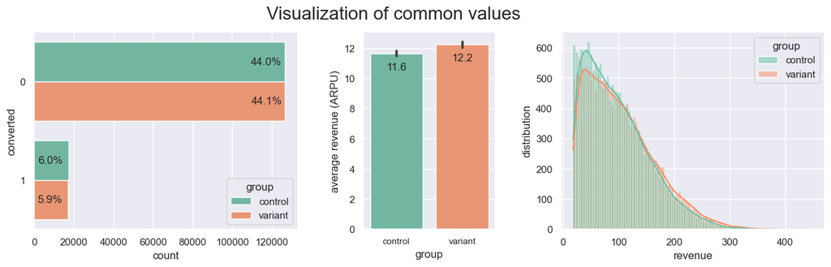

```python
sns.set(context='notebook', style='darkgrid', palette='Set2', font='sans-serif', font_scale=1, color_codes=False, rc=None)
# sns.set_theme(style="whitegrid")
fig, (ax1, ax2, ax3) = plt.subplots(1,3,figsize=(11,4), dpi=100, sharex=False, gridspec_kw={'width_ratios': [2, 1, 2]})
plt.subplots_adjust(wspace=0.3, hspace=1, left=0, right=1.1)
plt.suptitle('Visualization of common values', fontsize=20)
#Converted
plt.subplot(131)
ax1 = sns.countplot(data=df, y='converted', hue='group', order=[0, 1])
total_len = len(df)
for p in ax1.patches:
    percentage = f'{(100 * p.get_width() / total_len):.1f}%'
    y = p.get_y() + p.get_height() / 2
    x = p.get_width()
    ax1.annotate(percentage, (x, y), ha='center', va='center', xytext=(-20, 0), textcoords='offset points')

# Average revenue
plt.subplot(132)
ax2 = sns.barplot(data=df, x='group', y='revenue')
ax2 = plt.gca()
ax2.xaxis.set_tick_params(rotation=0, labelsize=10)
for rect in ax2.patches:
    height = rect.get_height()
    rect.axes.annotate(f'{height:.1f}',
                        xy=(rect.get_x()+rect.get_width()/2., height),
                        xytext=(0, -20), textcoords='offset points',
                        ha='center', va='bottom')
plt.ylabel('average revenue (ARPU)', size=12)
# Distribution vs Revenue
plt.subplot(133)
ax3 = sns.histplot(data=df[df.revenue > 0], x='revenue', hue='group', kde=True, bins=100)
plt.ylabel('distribution', size=12);
```

> **The subjective conclusions based on the visualization without data cleansing are as follows:**
> - The conversion on the `new` site is even slightly lower.
> - The number of clients is approximately equal.
> - The average `revenue` in the `variant` group is higher.
> - The distribution of `revenue` is obviously not normal.
> - The `revenue` indicator in the `control` group is biased towards smaller amounts, while in the `variant` group there are more customers with a larger check.

### `1.5` Let's convert it into a cleaned dataset: remove sampling errors, duplicates.

```python
# The number of times the wrong sites were ordered to the groups.
variant_error = df[((df['group']=='variant') & (df['site']!='new'))]
control_error =  df[((df['group']=='control') & (df['site']!='old'))]
print (f"The number of times variant group and new site don't line up is {variant_error.shape[0]} for the amount >>> {variant_error.revenue.sum()}")
print (f"The number of times control group and old site don't line up is {control_error.shape[0]} for the amount >>> {control_error.revenue.sum()}")
print (f"Percentage of mismatch errors >>> {round(((variant_error.shape[0]+control_error.shape[0])/df.shape[0]*100), 2)}%")
```

```
The number of times variant group and new site don't line up is 1916 for the amount >>> 26130.309999999998
The number of times control group and old site don't line up is 1893 for the amount >>> 22585.78
Percentage of mismatch errors >>> 1.32%
```

```python
# Remove sampling errors by creating a new dataset
df_new=df[~(((df['group']=='variant') & (df['site']!='new'))|((df['group']=='control') & (df['site']!='old')))]
```

```python
# Recheck
df_new[((df_new['group'] == 'variant') == (df_new['site'] == 'new')) == False].shape[0]
```

```
0
```

It looks like there is still rows of duplicates for `user_id`

```python
df_new['user_id'].duplicated().sum()
```

```
2
```

```python
df_new[df_new.duplicated(subset='user_id', keep=False)]
```

|  | user_id | timestamp | group | site | converted | country | revenue |
| --- | --- | --- | --- | --- | --- | --- | --- |
| 54345 | 773192 | 2023-01-14 02:55:59.590927 | variant | new | 0 | US | 0.0000000000 |
| 146723 | 926415 | 2023-01-11 13:36:20.372138 | variant | new | 0 | UK | 0.0000000000 |
| 208617 | 926415 | 2023-01-11 13:36:20.372138 | variant | new | 0 | UK | 0.0000000000 |
| 228692 | 773192 | 2023-01-09 05:37:58.781806 | variant | new | 0 | US | 0.0000000000 |

```python
# Remove one of the rows with a duplicate user_id..
df_new = df_new.drop_duplicates('user_id')
```

Now let's review the total number of rows and the number of unique users in the df_new dataset after its cleaning.

```python
print("number of rows: {}".format(df_new.shape[0]))
print("number of unique users: {}".format(df_new['user_id'].nunique()))
```

```
number of rows: 283745
number of unique users: 283745
```

> **The dataset has been cleaned and prepared for further work.**

#### Shorten the name of the dataset

```python
df = df_new.copy(deep=True)
```

### `1.6` Group Conversion Rate / ARPU / ARPPU

```python
indicators = df.groupby(['group'], as_index=False).agg(number_of_users = ('user_id', lambda x: len(x)),
                                                number_of_pay_users = ('revenue', lambda x: x[x > 0].count()),
                                                revenue = ('revenue', lambda x: sum(x)),
                                                cr = ('revenue', lambda x: x[x > 0].count()/len(x)),
                                                arpu = ('revenue', lambda x: x.sum()/len(x)),
                                                arppu = ('revenue', lambda x: x[x>0].sum()/len(x[x>0])))
indicators
```

|  | group | number_of_users | number_of_pay_users | revenue | cr | arpu | arppu |
| --- | --- | --- | --- | --- | --- | --- | --- |
| 0 | control | 141855 | 17091 | 1650560.8000000075 | 0.1204821825 | 11.6355489761 | 96.5748522614 |
| 1 | variant | 141890 | 16862 | 1732847.6199999927 | 0.1188385369 | 12.2126127282 | 102.7664345866 |

### `1.7` Viewing the Cleaned Dataset

```python
df[df.revenue > 0].describe().style.background_gradient(cmap='Greys')
```

|  | user_id | converted | revenue |
| --- | --- | --- | --- |
| count | 33953.000000 | 33953.000000 | 33953.000000 |
| mean | 788492.022914 | 1.000000 | 99.649763 |
| std | 91366.744042 | 0.000000 | 59.900501 |
| min | 630001.000000 | 1.000000 | 17.990000 |
| 25% | 709745.000000 | 1.000000 | 51.160000 |
| 50% | 787808.000000 | 1.000000 | 88.720000 |
| 75% | 867921.000000 | 1.000000 | 135.770000 |
| max | 945991.000000 | 1.000000 | 449.500000 |

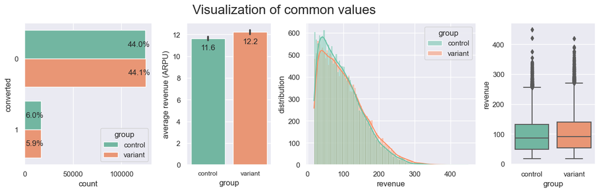

```python
sns.set(context='notebook', style='darkgrid', palette='Set2', font='sans-serif', font_scale=1, color_codes=False, rc=None)
# sns.set_theme(style="whitegrid")
fig, (ax1, ax2, ax3, ax4) = plt.subplots(1, 4, figsize=(11,4), dpi=100, sharex=False, gridspec_kw={'width_ratios': [1.5, 1, 2, 1]})
plt.subplots_adjust(wspace=0.3, hspace=1, left=0, right=1.1)
plt.suptitle('Visualization of common values', fontsize=20)
#Converted
plt.subplot(141)
ax1 = sns.countplot(data=df, y='converted', hue='group', order=[0, 1])
total_len = len(df)
for p in ax1.patches:
    percentage = f'{(100 * p.get_width() / total_len):.1f}%'
    y = p.get_y() + p.get_height() / 2
    x = p.get_width()
    ax1.annotate(percentage, (x, y), ha='center', va='center', xytext=(-10, 0), textcoords='offset points')

# Average revenue
plt.subplot(142)
ax2 = sns.barplot(data=df, x='group', y='revenue')
ax2 = plt.gca()
ax2.xaxis.set_tick_params(rotation=0, labelsize=10)
for rect in ax2.patches:
    height = rect.get_height()
    rect.axes.annotate(f'{height:.1f}',
                        xy=(rect.get_x()+rect.get_width()/2., height),
                        xytext=(0, -20), textcoords='offset points',
                        ha='center', va='bottom')
plt.ylabel('average revenue (ARPU)', size=12)
# Distribution vs Revenue
plt.subplot(143)
ax3 = sns.histplot(data=df[df.revenue > 0], x='revenue', hue='group', kde=True, bins=100)
plt.ylabel('distribution', size=12)
#Boxplot
plt.subplot(144)
ax4 = sns.boxplot(data = df[df.revenue > 0], y = 'revenue', x = 'group');
```

HOME || Part I - Exploratory Data Analysis(EDA) & Probability

# Part II - A/B Test

An A/B test compares data samples to determine if there is a difference between them.  
We are testing the old and new webpages. In this section, we will conduct tests on the parameters *Converted* and *Revenue*.

#### Contents:

- `2.1` Define Control Group & Test Group
- `2.2` Outliers

**`converted` *Conversion Rate*:**

- `2.3.1` Bootstrap
- `2.3.2` Binomial test
- `2.4`.Z-test

**`revenue` *Conversion Income*:**

- `2.3.3` Bootstrap
- `2.5` Shapiro Test
- `2.6`.Mann-Whitney Test:

#### The base assumption is that the new page is no better than the old page, unless we can prove with 95% certainty that the new page is definitely better. Except that we can make Type 1 errors with an "α" factor of 0.05 or 5%. This will be our null hypothesis and the alternative hypothesis (**$H_0$** and **$H_1$**) as follows:

1. The Null Hypotheses: P_new - P_old <= 0: $$H_0: P_{new} - P_{old} \leq 0 $$
2. The Alternative Hypotheses: P_new - P_old > 0: $$H_1: P_{new} - P_{old} > 0 $$

### `2.1` Define Control Group & Test Group

**Let's divide the dataset into samples that will be further used in tests.**

```python
'''Variant|Control --> only values from column CONVERTED --> 0|1 '''
variant_converted = df[df['group'] == 'variant']['converted']
control_converted = df[df['group'] == 'control']['converted']
```

```python
'''Variant|Control --> only values from column REVENUE --> 0|values '''
variant = df.loc[(df.group == 'variant'), 'revenue']
control = df.loc[(df.group == 'control'), 'revenue']
```

```python
'''Variant|Control --> only values from column REVENUE --> values>0 '''
variant_rev = df.loc[(df.group == 'variant') & (df.revenue > 0), 'revenue']
control_rev = df.loc[(df.group == 'control') & (df.revenue > 0), 'revenue']
```

**Samples without data outliers can be found here:** **Datasets without outliers**

### `2.3` Outliers

The charts show Outliers in `revenue` values, which can be removed for individual samples.  
Let's define quartiles. We will remove approximately 1% of the values that exceed the 1.5 interquantile range.

```python
df_all_rev = df[df.revenue > 0]
quartile1 = df_all_rev['revenue'].quantile(0.25)
quartile3 = df_all_rev['revenue'].quantile(0.75)
interquantile_range = quartile3 - quartile1
min_y = quartile3 + 1.5*interquantile_range
max_val = df_all_rev['revenue'].max()
max_y = max_val + (max_val*0.1)
# Confidence interval for the 'REVENUE' value
sms.DescrStatsW(df_all_rev['revenue']).tconfint_mean()
```

```
(99.01259404075134, 100.28693295244511)
```

```python
quartile_99 = df_all_rev['revenue'].quantile(0.99)
df_all_rev_99 = df_all_rev[df_all_rev.revenue < quartile_99]
# Confidence interval for the 'REVENUE' value
sms.DescrStatsW(df_all_rev_99['revenue']).tconfint_mean()
```

```
(97.03914402104104, 98.25162324162511)
```

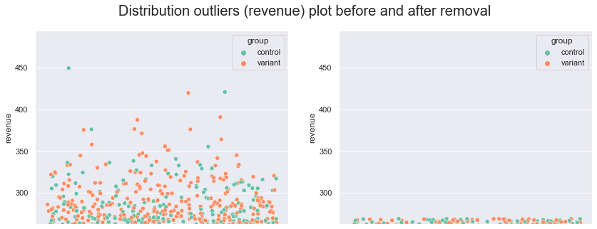

```python
plt.figure(figsize=(14,5))
plt.suptitle('Distribution outliers (revenue) plot before and after removal', fontsize=20)
plt.subplot(121)
sns.scatterplot(data=df_all_rev, x='user_id', y='revenue', hue='group')
plt.ylim(min_y, max_y)
ax = plt.gca()
ax.get_xaxis().set_visible(False)
plt.subplot(122)
sns.scatterplot(data=df_all_rev_99, x='user_id', y='revenue', hue='group')
plt.ylim(min_y, max_y)
ax = plt.gca()
ax.get_xaxis().set_visible(False);
```

**Create data samples without outliers:</br>**

```python
'''Full data set without outliers --> values<99%'''
df_all_99 = df[df.revenue < quartile_99]

'''Variant|Control --> only values from column REVENUE --> 0|values '''
variant_99 = df_all_99[df_all_99['group'] == 'variant']['revenue']
control_99 = df_all_99[df_all_99['group'] == 'control']['revenue']

'''Variant|Control --> only values from column REVENUE --> values>0 '''
variant_rev_99 = df_all_99.loc[(df.group == 'variant') & (df.revenue > 0), 'revenue']
control_rev_99 = df_all_99.loc[(df.group == 'control') & (df.revenue > 0), 'revenue']

'''Variant|Control --> only values from column CONVERTED --> 0|1 '''
variant_converted_99 = df_all_99[df_all_99['group'] == 'variant']['converted']
control_converted_99 = df_all_99[df_all_99['group'] == 'control']['converted']
```

```python
print(f'Number of data values removed from VARIANT: {variant.size-variant_99.size} | {round(((variant.size-variant_99.size)/variant.size)*100, 2)}%')
print(f'Number of data values removed from CONTROL: {control.size-control_99.size} | {round(((control.size-control_99.size)/control.size)*100, 2)}%')
```

```
Number of data values removed from VARIANT: 224 | 0.16%
Number of data values removed from CONTROL: 116 | 0.08%
```

```python
indicators_99 = df_all_99.groupby(['group'], as_index=False).agg(number_of_users = ('user_id', lambda x: len(x)),
                                                number_of_pay_users = ('revenue', lambda x: x[x > 0].count()),
                                                revenue = ('revenue', lambda x: sum(x)),
                                                cr = ('revenue', lambda x: x[x > 0].count()/len(x)),
                                                arpu = ('revenue', lambda x: x.sum()/len(x)),
                                                arppu = ('revenue', lambda x: x[x>0].sum()/len(x[x>0])))
indicators_99
```

|  | group | number_of_users | number_of_pay_users | revenue | cr | arpu | arppu |
| --- | --- | --- | --- | --- | --- | --- | --- |
| 0 | control | 141739 | 16975 | 1616055.7600000068 | 0.1197623801 | 11.4016308849 | 95.2021066274 |
| 1 | variant | 141666 | 16638 | 1666098.5199999933 | 0.1174452586 | 11.7607507800 | 100.1381488160 |

### `2.3` Bootstrap

`1` To bootstrap the sample

`2` Then simulate normal distributation under the null hypothesis with the center of the simulation closest to the alternative ( in our case zero) and standard deviation equal to sampling distribution ( in our case bootstraping sample standard deviation)

`3` Then we visualize the distributions

#### By this method, we compare in two parameters:

- Conversion rate
- Revenue

### `2.3.1` Conversion Rate. Bootstrap

```python
# Let's calculate the actual difference between the conversion rates for the two groups
p_new_con = df[df.group == 'variant']['converted'].mean()
print("Converted rate new group is {}".format (p_new_con))
p_old_con = df[df.group == 'control']['converted'].mean()
print("Converted rate control group is {}".format (p_old_con))
# cr_diff = g['cr']['variant']-g['cr']['control']

cr_diff = p_new_con - p_old_con
print("\nThe actual difference between the conversion rates of the two groups is {}".format (cr_diff))
```

```
Converted rate new group is 0.11883853689477765
Converted rate control group is 0.12048218251030983

The actual difference between the conversion rates of the two groups is -0.00164364561553218
```

```python
n_new=len(variant)
print( "New page users number is {}".format(n_new))
```

```
New page users number is 141890
```

```python
n_old=len(control)
print( "Old page users number is {}".format(n_old))
```

```
Old page users number is 141855
```

```python
# Sampling distribution
p_diffs_con = []

for i in tqdm(range(1000)):
    sample_new_page = np.random.choice([1, 0], size=n_new, p=[p_new_con, 1-p_new_con], replace= True)
    sample_old_page = np.random.choice([1, 0], size=n_old, p=[p_old_con, 1-p_old_con], replace= True)
    p_diffs_con.append(sample_new_page.mean() - sample_old_page.mean())

p_diffs_con = np.array(p_diffs_con) # convert to numpy array
```

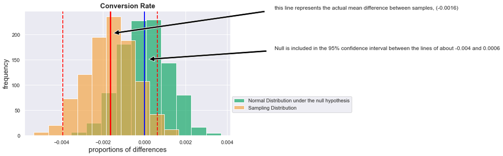

```python
#Looking at the sampling distribution as a normal distribution under the null hypothesis through the histogram
null_vals_con= np.random.normal(0, p_diffs_con.std(), p_diffs_con.size)

low, high = np.percentile(null_vals_con, 2.5), np.percentile(null_vals_con, 97.5)
low2, high2 = np.percentile(p_diffs_con, 2.5), np.percentile(p_diffs_con, 97.5)
plt.figure(figsize=(8,5))

green = plt.hist(null_vals_con, color='#0ca663AA', label='Normal Distribution under the null hypothesis')
orange = plt.hist(p_diffs_con, color='#f5a442AA', label='Sampling Distribution')
# plt.axvline(x= low, color= 'b', linewidth= 2, ls='--')
# plt.axvline(x= high, color= 'b', linewidth= 2, ls='--')
plt.axvline(x= low2, color= 'r', linewidth= 2, ls='--')
plt.axvline(x= high2, color= 'r', linewidth= 2, ls='--')
plt.axvline(x= 0, color= 'b', linewidth= 2)
plt.annotate(f'Null is included in the 95% confidence interval between the lines of about {round((low2), 4)} and {round((high2), 4)}',
                fontsize=12, xy=(-0.0001, 150), xytext=(0.0063, 170), arrowprops=dict(facecolor='black', shrink=0.05))
plt.axvline(cr_diff, c="red", linewidth= 3)
plt.annotate(f'this line represents the actual mean difference between samples, ({round((cr_diff), 4)})', fontsize=12,
             xy=(-.0019, 200), xytext=(0.0063, 250), arrowprops=dict(facecolor='black', shrink=0.05))
plt.title('Conversion Rate',fontsize=15, fontweight="bold")
plt.xlabel('proportions of differences', fontsize=15)
plt.ylabel('frequency', fontsize=15)
plt.legend(loc=5, bbox_to_anchor=(1.1, 0., 0.5, 0.5));
```

```python
print("The p-value is: {}".format((null_vals_con > cr_diff).mean()))
```

```
The p-value is: 0.928
```

#### Looking at the red vertical line, which expresses the place where our observed statistic is located, it is very close to the null value or the null hypothesis, and thus it is a confirmation that there is no significant difference in the observations of both pages.

### `2.3.2` Binomial Test

**We can also do the same previous simulation process using another method which is `random.binomial()`, since our hypothesis experiment is a binary experiment, we can use the random method `random.binomial()` to make simulations for both groups, where in this method we do not need to do a smoothing process and iterative simulation, because these iterations are already set Within the method itself, and therefore does not take much time in processing operations, as follows:** </br>

```python
sample_new=np.random.binomial(n_new,p_new_con,10000)/n_new
sample_old=np.random.binomial(n_old,p_old_con,10000)/n_old

diff_bi= sample_new - sample_old
diff_bi = np.array(diff_bi) # convert to numpy array
```

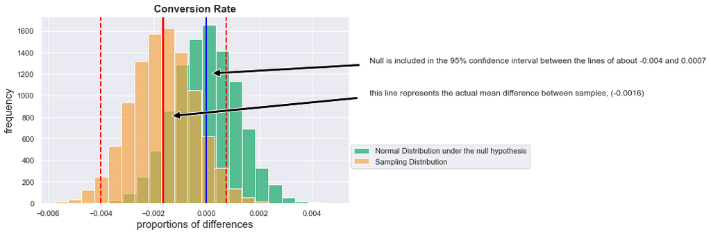

```python
#Looking at the sampling distribution as a normal distribution under the null hypothesis through the histogram
null_vals_bi = np.random.normal(0, diff_bi.std(), diff_bi.size)
low, high = np.percentile(null_vals_bi, 2.5), np.percentile(null_vals_bi, 97.5)
low2, high2 = np.percentile(diff_bi, 2.5), np.percentile(diff_bi, 97.5)
plt.figure(figsize=(8,5))

green = plt.hist(null_vals_bi, bins=20, color='#0ca663AA', label='Normal Distribution under the null hypothesis')
orange = plt.hist(diff_bi, bins=20, color='#f5a442AA', label='Sampling Distribution')
# plt.axvline(x= low, color= 'b', linewidth= 2, ls='--')
# plt.axvline(x= high, color= 'b', linewidth= 2, ls='--')
plt.axvline(x= low2, color= 'r', linewidth= 2, ls='--')
plt.axvline(x= high2, color= 'r', linewidth= 2, ls='--')
plt.axvline(x= 0, color= 'b', linewidth= 2)
plt.annotate(f'Null is included in the 95% confidence interval between the lines of about {round((low2), 4)} and {round((high2), 4)}',
             fontsize=12, xy=(-0.0001, 1200), xytext=(0.0062, 1300), arrowprops=dict(facecolor='black', shrink=0.05))
plt.axvline(cr_diff, c="red", linewidth= 3)
plt.annotate(f'this line represents the actual mean difference between samples, ({round((cr_diff), 4)})',
             fontsize=12, xy=(-.0017, 800), xytext=(0.0062, 1000), arrowprops=dict(facecolor='black', shrink=0.05))
plt.title('Conversion Rate',fontsize=15, fontweight="bold")
plt.xlabel('proportions of differences', fontsize=15)
plt.ylabel('frequency', fontsize=15)
plt.legend(loc=5, bbox_to_anchor=(1.1, 0., 0.5, 0.5));
```

```python
print("The p-value is: {}".format((null_vals_bi > cr_diff).mean()))
```

```
The p-value is: 0.9124
```

**We find that he is considered to have extracted and displayed the same results as the previous method.**

> **Based on the above, we fail to reject the null hypothesis (𝐻0) , which on the other hand means that there is `no difference` in the observations of both pages, and that the conversion rate of the new page is `not` really greater than the `conversion rate` of the old page.**

### `2.3.3` Revenue. Bootstrap

**The matter does not stop at these methods only, there is also a third way to do the same simulation using the `sample()` method, it is more accurate and comprehensive in extracting the results because we are simulating and booting from a real sample in our data set, but it takes a lot of time in processing operations, as follows:**

```python
# Let's calculate the actual difference between the revenue for the two groups
p_new_revenue = variant.mean()
print("Average revenue in the variant group is {}".format (p_new_revenue))
p_old_revenue = control.mean()
print("Average revenue in the control group is {}".format (p_old_revenue))

arpu_diff = p_new_revenue-p_old_revenue
print("\nThe actual difference between the median revenue of the two groups is {}".format (arpu_diff))
```

```
Average revenue in the variant group is 12.212612728169658
Average revenue in the control group is 11.635548976067163

The actual difference between the median revenue of the two groups is 0.5770637521024948
```

```python
# bootstraping the sample to get new samples and calculate new p values and difference for each point
p_diffs_revenue=[]
for i in tqdm(range(1000)):
    bootsample = df.sample(df.shape[0],replace=True)
    p_new_revenue=bootsample[bootsample['group']=='variant']['revenue'].mean()
    p_old_revenue=bootsample[bootsample['group']=='control']['revenue'].mean()
    p_diff_revenue=p_new_revenue-p_old_revenue
    p_diffs_revenue.append(p_diff_revenue)

p_diffs_revenue = np.array(p_diffs_revenue)  # convert to numpy array
```

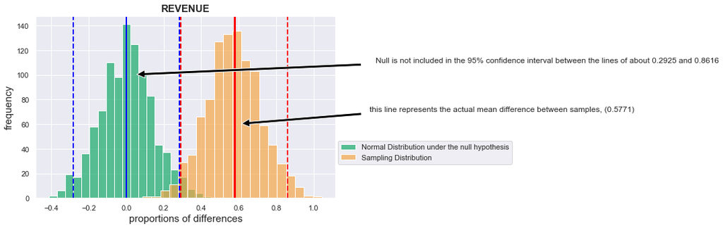

```python
#Looking at the sampling distribution as a normal distribution under the null hypothesis through the histogram
null_vals_revenue = np.random.normal(0, p_diffs_revenue.std(), p_diffs_revenue.size)

low, high = np.percentile(null_vals_revenue, 2.5), np.percentile(null_vals_revenue, 97.5)
low2, high2 = np.percentile(p_diffs_revenue, 2.5), np.percentile(p_diffs_revenue, 97.5)

plt.figure(figsize=(8,5))

green = plt.hist(null_vals_revenue, bins=20, color='#0ca663AA', label='Normal Distribution under the null hypothesis')
orange = plt.hist(p_diffs_revenue, bins=20, color='#f5a442AA', label='Sampling Distribution')
plt.axvline(x= low, color= 'b', linewidth= 2, ls='--')
plt.axvline(x= high, color= 'b', linewidth= 2, ls='--')
plt.axvline(x= low2, color= 'r', linewidth= 2, ls='--')
plt.axvline(x= high2, color= 'r', linewidth= 2, ls='--')
plt.axvline(x= 0, color= 'b', linewidth= 2)
plt.annotate(f'Null is not included in the 95% confidence interval between the lines of about {round((low2), 4)} and {round((high2), 4)}',
             fontsize=12, xy=(-.01, 100), xytext=(1.33, 110), arrowprops=dict(facecolor='black', shrink=0.05))
plt.axvline(arpu_diff, c="red", linewidth= 3)
plt.annotate(f'this line represents the actual mean difference between samples, ({round((arpu_diff), 4)})', fontsize=12,
             xy=(.58, 60), xytext=(1.3, 70), arrowprops=dict(facecolor='black', shrink=0.05))
plt.title('REVENUE',fontsize=15, fontweight="bold")
plt.xlabel('proportions of differences', fontsize=15)
plt.ylabel('frequency', fontsize=15)
plt.legend(loc=5, bbox_to_anchor=(1.1, 0., 0.5, 0.5));
```

```python
print("The p-value is: {:.9f}".format((null_vals_revenue > arpu_diff).mean()))
```

```
The p-value is: 0.000000000
```

#### Looking at the red vertical line that shows where our observed statistic is, it is very far from the null value or null hypothesis. Thus confirms the existence of a significant difference in the observations of both pages.

The p value is 0, which may indicate the maximum sample difference.

### Now let's tighten up the requirements. Let's compare samples without data outliers.

```python
# Let's calculate the actual difference between the revenue for the two groups
p_99_new_revenue = variant_99.mean()
print("Average revenue in the variant group is {}".format (p_99_new_revenue))
p_99_old_revenue = control_99.mean()
print("Average revenue in the control group is {}".format (p_99_old_revenue))

arpu_diff_99 = p_99_new_revenue-p_99_old_revenue
print("\nThe actual difference between the median revenue of the two groups is {}".format (arpu_diff_99))
```

```
Average revenue in the variant group is 11.760750780003622
Average revenue in the control group is 11.401630884936445

The actual difference between the median revenue of the two groups is 0.35911989506717745
```

```python
# bootstraping the sample to get new samples and calculate new p values and difference for each point
p_99_diffs_revenue=[]
for i in tqdm(range(1000)):
    bootsample_99 = df_all_99.sample(df_all_99.shape[0],replace=True)
    p_99_new_revenue=bootsample_99[bootsample_99['group']=='variant']['revenue'].mean()
    p_99_old_revenue=bootsample_99[bootsample_99['group']=='control']['revenue'].mean()
    p_99_diff_revenue=p_99_new_revenue - p_99_old_revenue
    p_99_diffs_revenue.append(p_99_diff_revenue)

p_99_diffs_revenue = np.array(p_99_diffs_revenue)  # convert to numpy array
```

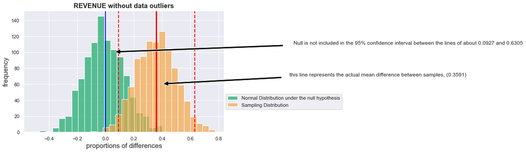

```python
#Looking at the sampling distribution as a normal distribution under the null hypothesis through the histogram
null_vals_revenue = np.random.normal(0, p_99_diffs_revenue.std(), p_99_diffs_revenue.size)

low, high = np.percentile(null_vals_revenue, 2.5), np.percentile(null_vals_revenue, 97.5)
low2, high2 = np.percentile(p_99_diffs_revenue, 2.5), np.percentile(p_99_diffs_revenue, 97.5)

plt.figure(figsize=(8,5))

green = plt.hist(null_vals_revenue, bins=20, color='#0ca663AA', label='Normal Distribution under the null hypothesis')
orange = plt.hist(p_99_diffs_revenue, bins=20, color='#f5a442AA', label='Sampling Distribution')
# plt.axvline(x= low, color= 'b', linewidth= 2, ls='--')
# plt.axvline(x= high, color= 'b', linewidth= 2, ls='--')
plt.axvline(x= low2, color= 'r', linewidth= 2, ls='--')
plt.axvline(x= high2, color= 'r', linewidth= 2, ls='--')
plt.axvline(x= 0, color= 'b', linewidth= 2)
plt.annotate(f'Null is not included in the 95% confidence interval between the lines of about {round((low2), 4)} and {round((high2), 4)}',
             fontsize=12, xy=(.001, 100), xytext=(1.33, 110), arrowprops=dict(facecolor='black', shrink=0.05))
plt.axvline(arpu_diff_99, c="red", linewidth= 3)
plt.annotate(f'this line represents the actual mean difference between samples, ({round((arpu_diff_99), 4)})', fontsize=12,
             xy=(.36, 60), xytext=(1.3, 70), arrowprops=dict(facecolor='black', shrink=0.05))
plt.title('REVENUE without data outliers',fontsize=15, fontweight="bold")
plt.xlabel('proportions of differences', fontsize=15)
plt.ylabel('frequency', fontsize=15)
plt.legend(loc=5, bbox_to_anchor=(1.1, 0., 0.5, 0.5));
```

```python
print("The p-value is: {}".format((null_vals_revenue > arpu_diff_99).mean()))
```

```
The p-value is: 0.007
```

#### The p-value is 0.007, which may indicate a statistically significant difference.

> After carrying out `bootstrap` tests, we can accept the hypothesis (𝐻1).  
> Using the `new` website page resulted in better `revenue` results.

### `2.4` Z-test: Conversion Rate.

**Now use `sm.stats.proportions_ztest()` to compute your test statistic and p-value. [Here](https://www.statsmodels.org/stable/generated/statsmodels.stats.proportion.proportions_ztest.html) is a helpful link on using the built in.**

The syntax is:

```
proportions_ztest(count_array, nobs_array, alternative='larger')
```

where,

- `count_array` = represents the number of "converted" for each group
- `nobs_array` = represents the total number of observations (rows) in each group
- `alternative` = choose one of the values from `[‘two-sided’, ‘smaller’, ‘larger’]` depending upon two-tailed, left-tailed, or right-tailed respectively.

  > **Hint**:  
  > It's a two-tailed if you defined $H_1$ as $(p_{new} = p_{old})$.  
  > It's a left-tailed if you defined $H_1$ as $(p_{new} < p_{old})$.  
  > It's a right-tailed if you defined $H_1$ as $(p_{new} > p_{old})$.

```python
# number of conversions with the new_page
convert_new = variant_converted.sum()
# number of conversions with the old_page
convert_old = control_converted.sum()
print(f'Number of "converted" for each group >>> convert_old: {convert_old}, convert_new: {convert_new}')
print(f'Total number of observations (rows) in each group >>> n_old: {n_old}, n_new: {n_new}')
```

```
Number of "converted" for each group >>> convert_old: 17091, convert_new: 16862
Total number of observations (rows) in each group >>> n_old: 141855, n_new: 141890
```

```python
# import statsmodels.api as sm
z_score, p_value = sm.stats.proportions_ztest([convert_new, convert_old], [n_new, n_old],alternative='larger')
print(z_score, p_value)
```

```
-1.3487832789439451 0.9112967064842583
```

**Z_score means the amount of standard deviation of our value from the mean. Therefore, in our case, the observed difference in the sample is -1.35 standard deviations to the left of the center of zero.**

Z-test is performed when the sample size is large, and the population variance is known. The z-score represents the distance between the two "converted" success rates in terms of the standard error.

Next step is to make a decision to reject or fail to reject the null hypothesis based on comparing these two values:

- $Z_{score}$
- $Z_{\alpha}$ or $Z_{0.05}$, also known as critical value at 95% confidence interval. $Z_{0.05}$ is 1.645 for one-tailed tests, and 1.960 for two-tailed test. You can determine the $Z_{\alpha}$ from the z-table manually.

Decide if your hypothesis is either a two-tailed, left-tailed, or right-tailed test. Accordingly, reject OR fail to reject the null based on the comparison between $Z_{score}$ and $Z_{\alpha}$. We determine whether or not the $Z_{score}$ lies in the "rejection region" in the distribution. In other words, a "rejection region" is an interval where the null hypothesis is rejected iff the $Z_{score}$ lies in that region.

Hint: For a right-tailed test, reject null if $Z_{score}$ > $Z_{\alpha}$. For a left-tailed test, reject null if $Z_{score}$ < $Z_{\alpha}$.

Now we need to extract the value of $Z_{\alpha}$, which is "α" by 0.05 but after converting it to a standardized value, through the `scipy` library as follows:

```python
# from scipy import stats

Za= stats.norm.ppf(1-0.05)
Za
```

```
1.6448536269514722
```

**Our test is based on the `right` tailed.**

**The comparison between $Z_{score}$ and $Z_{\alpha}$ is made based on the following:**

- For a right-tailed test, reject null hypothesis if $Z_{score}$ > $Z_{\alpha}$.
- For a left-tailed test, reject null hypothesis if $Z_{score}$ < $Z_{\alpha}$.

Now let's compare the two values using the following graph:

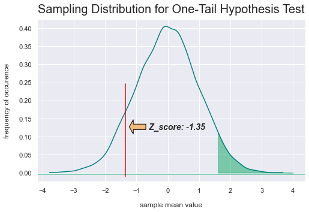

```python
#Generate symmetrically two-sided random numbers with a mean of 0 and a standard deviation of 1
# import scipy.stats as stats
values = np.random.normal(loc=0, scale= 1, size=10000)

plt.rcParams["figure.figsize"] = [8, 5]
two_std_from_mean = np.mean(values) + np.std(values)*Za
kde = stats.gaussian_kde(values)
pos = np.linspace(np.min(values), np.max(values), 10000)
plt.plot(pos, kde(pos), color='teal')
shade = np.linspace(two_std_from_mean, 4, 300)
plt.fill_between(shade, kde(shade), alpha=0.50, color='#0ca663AA')
plt.axhline(-0.004)
plt.axvline(z_score, ymin= 0.03, ymax= 0.6, c='r')
plt.text(-0.6, 0.12, "Z_score: {0:.{digits}f}".format(z_score, digits= 2), fontsize=14, fontweight="bold", fontstyle="italic")
plt.arrow(-0.7, 0.127, -0.4, 0, head_length= 0.13, head_width = -0.04, width = -0.015, ec="k", color='#f5a442AA')
plt.title("Sampling Distribution for One-Tail Hypothesis Test", y=1.015, fontsize=20)
plt.xlabel("sample mean value", labelpad=14)
plt.ylabel("frequency of occurence", labelpad=14);
```

**From the graph, we find that the line for the $Z_{score}$ region is not within the shaded region of $Z_{\alpha}$ which is the rejection region, and it is far from it.**

> **P_value = 0.91 > 0.05. The results are consistent with previous `conversion rate` findings. We cannot reject (𝐻0).**

### Let's compare samples without data outliers.

```python
# number of conversions with the new_page
convert_new_99 = variant_converted_99.sum()
# number of conversions with the old_page
convert_old_99 = control_converted_99.sum()
n_new_99 = variant_converted_99.size
n_old_99 = control_converted_99.size
print(f'Number of "converted" for each group >>> convert_old: {convert_old_99}, convert_new: {convert_new_99}')
print(f'Total number of observations (rows) in each group >>> n_old: {n_old_99}, n_new: {n_new_99}')
```

```
Number of "converted" for each group >>> convert_old: 16975, convert_new: 16638
Total number of observations (rows) in each group >>> n_old: 141739, n_new: 141666
```

```python
# import statsmodels.api as sm
z_score_99, p_value_99 = sm.stats.proportions_ztest([convert_new_99, convert_old_99], [n_new_99, n_old_99], alternative='larger')
print(z_score_99, p_value_99)
```

```
-1.9075993871409964 0.9717784927886728
```

**Obviously, the $Z_{score}$ = -1.91 and $P-{value}$ = 0.97 have only gotten worse.**

### `Attention!` But what if you try to conduct a hypothesis test that the new page `(sample without outliers)` led to a statistically significant decrease in *conversion*.

```python
# import statsmodels.api as sm
z_score_r, p_value_r = sm.stats.proportions_ztest([convert_old_99, convert_new_99], [n_old_99, n_new_99], alternative='larger')
print(z_score_r, p_value_r)
```

```
1.9075993871409964 0.028221507211327268
```

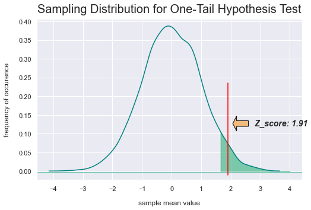

```python
#Generate symmetrically two-sided random numbers with a mean of 0 and a standard deviation of 1
values = np.random.normal(loc=0, scale= 1, size=10000)

plt.rcParams["figure.figsize"] = [8, 5]
two_std_from_mean = np.mean(values) + np.std(values)*Za
kde = stats.gaussian_kde(values)
pos = np.linspace(np.min(values), np.max(values), 10000)
plt.plot(pos, kde(pos), color='teal')
shade = np.linspace(two_std_from_mean, 4, 300)
plt.fill_between(shade, kde(shade), alpha=0.50, color='#0ca663AA')
plt.axhline(-0.004)
plt.axvline(z_score_r, ymin= 0.03, ymax= 0.6, c='r')
plt.text(2.8, 0.12, "Z_score: {0:.{digits}f}".format(z_score_r, digits= 2), fontsize=14, fontweight="bold", fontstyle="italic")
plt.arrow(2.6, 0.127, -0.4, 0, head_length= 0.13, head_width = -0.04, width = -0.015, ec="k", color='#f5a442AA')
plt.title("Sampling Distribution for One-Tail Hypothesis Test", y=1.015, fontsize=20)
plt.xlabel("sample mean value", labelpad=14)
plt.ylabel("frequency of occurence", labelpad=14);
```

! - For a right-tailed test, reject null hypothesis if $Z_{score}$ > $Z_{\alpha}$.  
Represent $Z_{score}$ = 1.91 > 1.645 and $P-{value}$ = 0.028 < 0.05  
If the task was to consider the hypothesis that a new page reduces conversion, then we could justify this.

> **Conclusions. In terms of `conversion rate` we cannot reject the null hypothesis. The new page does not increase the conversion.**

### `2.5` Check Normality: Shapiro Test

Procedure for successful testing:

- Using the Shapiro-Wilk test to check if each group was drawn from a normal distribution.
- If Normal distribution, Using Levene's test to check if k samples have equal variances (Homogeneity of variances).
- If Normal & homogeneity, apply T-test.
- If Normal but non-homogeneity, apply Welch Test
- If Non-Normal, apply Mann Whitney U Test.

We have previously concluded that the distribution is not normal.  
Nevertheless, let's check the `revenue` distribution with a test.

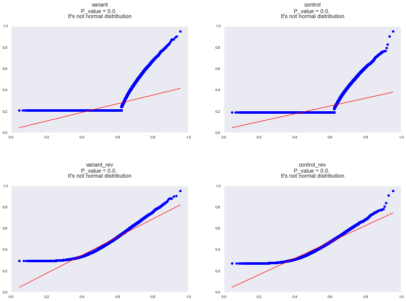

```python
# Visual Shapiro Test
import math

dict_sample = [variant, control, variant_rev, control_rev]
title_sample = ['variant', 'control', 'variant_rev', 'control_rev']
cols = 2
rows = math.ceil(len(dict_sample) / cols)

fig, axes = plt.subplots(rows, cols, figsize=(20, 14), dpi=50)
plt.subplots_adjust(wspace=0.2, hspace=0.5)

l = 0
for i in range(rows):
    for j in range(cols):
        if len(dict_sample) == l:
            break
        else:
            sample = dict_sample[l]
            axes = fig.add_subplot(rows,cols,(l+1))
            stats.probplot(sample, dist="norm", plot=pylab)
            axes.get_yaxis().set_visible(False)
            axes.get_xaxis().set_visible(False)
            pv = shapiro(sample)
            if pv.pvalue > 0.05:
                plt.title(f"{title_sample[l]}\nP_value = {pv.pvalue}. \nIt's normal distribution\n", fontsize=16)
            else:
                plt.title(f"{title_sample[l]}\nP_value = {pv.pvalue}. \nIt's not normal distribution\n", fontsize=16)
            l += 1;
```

> **The distribution is `not normal` in any of the samples.**

### `2.6` Mann-Whitney Parametric Test: REVENUE. Check the equality of average income

**Let's check the value of the statistics of the Mann-Whitney test. Some sources have a limitation of applicability in case of duplicate data. There are a lot of zero values, so in this case we need to be careful about this criterion.**

Variants: Our sample groups

```python
def ab_test(variant, control):
    alpha = 0.05
    mannwhitney = mannwhitneyu(variant, control) #or alternative='greater'
    if mannwhitney.pvalue < alpha:
        print(f"\nP_value = {mannwhitney.pvalue:.8f} \n\nGroups is different. Reject the hypothesis of equality of average income.")
    else:
        print(f"\nP_value = {mannwhitney.pvalue:.8f}. \n\nGroups is similar. Accept the hypothesis of equality of average income.")
```

```python
ab_test(variant, control)
```

```
P_value = 0.46366617.

Groups is similar. Accept the hypothesis of equality of average income.
```

```python
ab_test(variant_99, control_99)
```

```
P_value = 0.17277886.

Groups is similar. Accept the hypothesis of equality of average income.
```

```python
ab_test(variant_rev, control_rev)
```

```
P_value = 0.00000000

Groups is different. Reject the hypothesis of equality of average income.
```

```python
ab_test(variant_rev_99, control_rev_99)
```

```
P_value = 0.00000000

Groups is different. Reject the hypothesis of equality of average income.
```

> **Conclusions of Mann-Whitney Parametric Test:**
> - **In terms of `Revenue for all users` we cannot reject the null hypothesis >> $H_0$.**
> - **In terms of `Revenue for all users without outliers` we cannot reject the null hypothesis >> $H_0$.**
> - **In terms of `Revenue for users who paid` we reject the null hypothesis >> $H_1$.**
> - **In terms of `Revenue for users who paid without outliers` we reject the null hypothesis >> $H_1$.**

HOME || Part II - A/B Test

## Part III - A regression approach

#### Contents:

- `3.1` AB_page
- `3.2` Country
- `3.3` AB_page & Country
- `3.4` Time periods & AB_page & Country

**The results obtained from the A/B test above can be achieved by performing a regression. A machine learning technique, like regression, takes a more personalized approach to inference by seeking to predict the outcome of each point in a given set of data.**
**Unlike previous tests, where the hypothesis was checked more > (or <) than the studied values, Logistic regression depends on the hypothesis about the occurrence of the event or not, in other words, it is equal or not equal to:**
$$H_0: P_{new} - P_{old} = 0 $$ $$H_1: P_{new} - P_{old}\neq 0 $$

- The variable `conversion` it has two values 0 or 1, it can be considered as a binary categorical variable.
- Other variables `group/site` and `country` can also be converted to binary values.
- Moreover, `timestamp` can also be split into, for example, morning, afternoon, evening, and converted to binary values.

**To predict categorical features, we will use Logistic Regression.**

```python
df.head(3)
```

|  | user_id | timestamp | group | site | converted | country | revenue |
| --- | --- | --- | --- | --- | --- | --- | --- |
| 0 | 890982 | 2023-01-02 18:34:54.592893 | control | old | 1 | UK | 34.8000000000 |
| 1 | 890746 | 2023-01-08 21:24:31.046958 | control | old | 0 | US | 0.0000000000 |
| 2 | 771387 | 2023-01-12 19:00:39.980267 | control | old | 0 | US | 0.0000000000 |

```python
df2 = df.copy(deep=True)
```

```python
df2_99 = df_all_99.copy(deep=True)
```

**Let's implement the `ab_page` variable, which is a dummy variable column that has a value of `1` when `variant` group and `0` otherwise when `control` group.**

```python
df2[['control', 'variant']]= pd.get_dummies(df2['group'])
df2.drop('control', axis= 1, inplace= True)
df2.rename(columns={'variant': 'ab_page'}, inplace= True)

df2_99[['control', 'variant']]= pd.get_dummies(df2_99['group'])
df2_99.drop('control', axis= 1, inplace= True)
df2_99.rename(columns={'variant': 'ab_page'}, inplace= True)
```

```python
df2.sample(5)
```

|  | user_id | timestamp | group | site | converted | country | revenue | ab_page |
| --- | --- | --- | --- | --- | --- | --- | --- | --- |
| 159314 | 665668 | 2023-01-21 16:15:57.295968 | control | old | 0 | US | 0.0000000000 | 0 |
| 40825 | 722188 | 2023-01-20 07:11:41.102321 | variant | new | 0 | US | 0.0000000000 | 1 |
| 34943 | 918111 | 2023-01-23 13:15:23.367228 | control | old | 0 | US | 0.0000000000 | 0 |
| 156542 | 837778 | 2023-01-10 00:55:10.982248 | control | old | 1 | US | 47.7400000000 | 0 |
| 79422 | 647257 | 2023-01-15 04:34:54.875354 | variant | new | 0 | US | 0.0000000000 | 1 |

**`3.1` Let's create an instance of the regression model for the two columns created above. And also create a column for another `intercept` variable and give it the values `1` for the entire column. Then fit the model to predict if it converts.**

```python
# import statsmodels.api as sm
df2['intercept'] = 1
model = sm.Logit(df2['converted'], df2[['intercept', 'ab_page']])
results = model.fit()
```

```
Optimization terminated successfully.
         Current function value: 0.366244
         Iterations 6
```

```python
results.summary2()
```

| Model: | Logit | Pseudo R-squared: | 0.000 |
| --- | --- | --- | --- |
| Dependent Variable: | converted | AIC: | 207843.9931 |
| Date: | 2023-05-21 15:12 | BIC: | 207865.1048 |
| No. Observations: | 283745 | Log-Likelihood: | -1.0392e+05 |
| Df Model: | 1 | LL-Null: | -1.0392e+05 |
| Df Residuals: | 283743 | LLR p-value: | 0.17740 |
| Converged: | 1.0000 | Scale: | 1.0000 |
| No. Iterations: | 6.0000 |  |  |

|  | Coef. | Std.Err. | z | P>\|z\| | [0.025 | 0.975] |
| --- | --- | --- | --- | --- | --- | --- |
| intercept | -1.9879 | 0.0082 | -243.7218 | 0.0000 | -2.0039 | -1.9719 |
| ab_page | -0.0156 | 0.0116 | -1.3488 | 0.1774 | -0.0383 | 0.0071 |

**Since the P-value of the logistic regression is 0.1774, this means we have no evidence of a difference in the conversion rates of the two pages.**

We note that the p-value of the coefficient ab_page is 0.1774, which is very different from the p-value extracted from the hypothesis tests of the previous methods, which was about 0.9.

```python
df2_99['intercept'] = 1
model_99 = sm.Logit(df2_99['converted'], df2_99[['intercept', 'ab_page']])
results_99 = model_99.fit()
```

```
Optimization terminated successfully.
         Current function value: 0.364128
         Iterations 6
```

```python
results_99.summary2()
```

| Model: | Logit | Pseudo R-squared: | 0.000 |
| --- | --- | --- | --- |
| Dependent Variable: | converted | AIC: | 206395.4577 |
| Date: | 2023-05-21 15:12 | BIC: | 206416.5669 |
| No. Observations: | 283405 | Log-Likelihood: | -1.0320e+05 |
| Df Model: | 1 | LL-Null: | -1.0320e+05 |
| Df Residuals: | 283403 | LLR p-value: | 0.056440 |
| Converged: | 1.0000 | Scale: | 1.0000 |
| No. Iterations: | 6.0000 |  |  |

|  | Coef. | Std.Err. | z | P>\|z\| | [0.025 | 0.975] |
| --- | --- | --- | --- | --- | --- | --- |
| intercept | -1.9947 | 0.0082 | -243.8252 | 0.0000 | -2.0107 | -1.9786 |
| ab_page | -0.0222 | 0.0116 | -1.9076 | 0.0564 | -0.0449 | 0.0006 |

**If we compare the samples without outliers, then the P-value was 0.0564, after all, more than 0.05. That is, we cannot recognize a statistically significant difference.**

### `3.2` Now, along with checking how the conversion rate changes across different pages, we'll add other `country` factors to see how the conversion rate affects the country the user is from.

Since the country column is a categorical variable containing three classes ['US','UK','CA'], we will create dummy variables for these classes, and then drop one of them and use the remaining two dummy variables, as follows:

```python
df2[['CA','UK','US']]=pd.get_dummies(df2['country']) # creating dummy_variables
```

```python
df2_99[['CA','UK','US']]=pd.get_dummies(df2_99['country']) # creating dummy_variables
```

```python
df2_99.head(2)
```

|  | user_id | timestamp | group | site | converted | country | revenue | ab_page | intercept | CA | UK | US |
| --- | --- | --- | --- | --- | --- | --- | --- | --- | --- | --- | --- | --- |
| 0 | 890982 | 2023-01-02 18:34:54.592893 | control | old | 1 | UK | 34.8000000000 | 0 | 1 | 0 | 1 | 0 |
| 1 | 890746 | 2023-01-08 21:24:31.046958 | control | old | 0 | US | 0.0000000000 | 0 | 1 | 0 | 0 | 1 |

```python
df2.groupby('country')[['converted']].mean()['converted'].nlargest()
```

```
country
UK   0.1209201647
US   0.1195173454
CA   0.1153791837
Name: converted, dtype: float64
```

We can see that the conversion rates across countries are very close to each other and almost equal, which predicts in advance that the country factor does not affect the conversion rate. Let's check.

We use two columns of countries for three dummy variables.

```python
# import statsmodels.api as sm
model = sm.Logit(df2['converted'], df2[['intercept', 'ab_page', 'UK', 'US' ]])
results = model.fit()

results.summary2()
```

```
Optimization terminated successfully.
         Current function value: 0.366238
         Iterations 6
```

| Model: | Logit | Pseudo R-squared: | 0.000 |
| --- | --- | --- | --- |
| Dependent Variable: | converted | AIC: | 207844.4130 |
| Date: | 2023-05-21 15:12 | BIC: | 207886.6363 |
| No. Observations: | 283745 | Log-Likelihood: | -1.0392e+05 |
| Df Model: | 3 | LL-Null: | -1.0392e+05 |
| Df Residuals: | 283741 | LLR p-value: | 0.14478 |
| Converged: | 1.0000 | Scale: | 1.0000 |
| No. Iterations: | 6.0000 |  |  |

|  | Coef. | Std.Err. | z | P>\|z\| | [0.025 | 0.975] |
| --- | --- | --- | --- | --- | --- | --- |
| intercept | -2.0291 | 0.0269 | -75.3426 | 0.0000 | -2.0819 | -1.9763 |
| ab_page | -0.0156 | 0.0116 | -1.3450 | 0.1786 | -0.0382 | 0.0071 |
| UK | 0.0531 | 0.0287 | 1.8494 | 0.0644 | -0.0032 | 0.1094 |
| US | 0.0399 | 0.0272 | 1.4664 | 0.1426 | -0.0134 | 0.0932 |

**Here we see that the LLR p-value value is 0.14478, which is greater than the "0.05", which indicates that the model in general is `not statistically significant`, which was confirmed when looking at the results of the p-values of the three coefficients that they are indeed all greater than 0.05, and that each of the coefficients UK and US do not have an increase effect on an individual's conversion rate.**

```python
model_99 = sm.Logit(df2_99['converted'], df2_99[['intercept', 'ab_page', 'UK', 'US' ]])
results_99 = model_99.fit()

results_99.summary2()
```

```
Optimization terminated successfully.
         Current function value: 0.364121
         Iterations 6
```

| Model: | Logit | Pseudo R-squared: | 0.000 |
| --- | --- | --- | --- |
| Dependent Variable: | converted | AIC: | 206395.4217 |
| Date: | 2023-05-21 15:12 | BIC: | 206437.6403 |
| No. Observations: | 283405 | Log-Likelihood: | -1.0319e+05 |
| Df Model: | 3 | LL-Null: | -1.0320e+05 |
| Df Residuals: | 283401 | LLR p-value: | 0.053229 |
| Converged: | 1.0000 | Scale: | 1.0000 |
| No. Iterations: | 6.0000 |  |  |

|  | Coef. | Std.Err. | z | P>\|z\| | [0.025 | 0.975] |
| --- | --- | --- | --- | --- | --- | --- |
| intercept | -2.0413 | 0.0271 | -75.2959 | 0.0000 | -2.0944 | -1.9881 |
| ab_page | -0.0221 | 0.0116 | -1.9036 | 0.0570 | -0.0449 | 0.0007 |
| UK | 0.0576 | 0.0289 | 1.9912 | 0.0465 | 0.0009 | 0.1142 |
| US | 0.0459 | 0.0274 | 1.6764 | 0.0937 | -0.0078 | 0.0996 |

For the `assembly without outliers`, we see that the p LLR value is 0.053, which is greater than "0.05", indicating that the model as a whole is not statistically significant.  
**However, when looking at the results of the p-values of the three coefficients, P-value `UK` 0.04 < 0.05, indicating a statistically significant effect on the conversion parameter.**

**`3.3` While you've looked at individual page and country factors regarding conversion, we'd now like to look at the interaction between page and country to see if it has a significant impact on conversion. Create the additional columns you need and fit the new model.**

Provide summary results and your conclusions based on the results.

```python
df2['ab_page&UK']=df2['ab_page']*df2['UK']
df2['ab_page&US']=df2['ab_page']*df2['US']
```

```python
df2_99['ab_page&UK']=df2_99['ab_page']*df2_99['UK']
df2_99['ab_page&US']=df2_99['ab_page']*df2_99['US']
```

```python
df2_99.tail(3)
```

|  | user_id | timestamp | group | site | converted | country | revenue | ab_page | intercept | CA | UK | US | ab_page&UK | ab_page&US |
| --- | --- | --- | --- | --- | --- | --- | --- | --- | --- | --- | --- | --- | --- | --- |
| 287553 | 794763 | 2023-01-15 21:47:46.723956 | control | old | 0 | US | 0.0000000000 | 0 | 1 | 0 | 0 | 1 | 0 | 0 |
| 287554 | 921807 | 2023-01-04 05:00:32.778781 | variant | new | 0 | US | 0.0000000000 | 1 | 1 | 0 | 0 | 1 | 0 | 1 |
| 287555 | 788446 | 2023-01-18 21:46:37.351102 | variant | new | 0 | US | 0.0000000000 | 1 | 1 | 0 | 0 | 1 | 0 | 1 |

```python
model = sm.Logit(df2['converted'], df2[['intercept', 'ab_page', 'UK', 'US', 'ab_page&UK', 'ab_page&US']])
results = model.fit()

results.summary2()
```

```
Optimization terminated successfully.
         Current function value: 0.366234
         Iterations 6
```

| Model: | Logit | Pseudo R-squared: | 0.000 |
| --- | --- | --- | --- |
| Dependent Variable: | converted | AIC: | 207846.1184 |
| Date: | 2023-05-21 15:12 | BIC: | 207909.4534 |
| No. Observations: | 283745 | Log-Likelihood: | -1.0392e+05 |
| Df Model: | 5 | LL-Null: | -1.0392e+05 |
| Df Residuals: | 283739 | LLR p-value: | 0.17393 |
| Converged: | 1.0000 | Scale: | 1.0000 |
| No. Iterations: | 6.0000 |  |  |

|  | Coef. | Std.Err. | z | P>\|z\| | [0.025 | 0.975] |
| --- | --- | --- | --- | --- | --- | --- |
| intercept | -2.0059 | 0.0369 | -54.3857 | 0.0000 | -2.0782 | -1.9336 |
| ab_page | -0.0624 | 0.0526 | -1.1855 | 0.2358 | -0.1655 | 0.0407 |
| UK | 0.0168 | 0.0403 | 0.4163 | 0.6772 | -0.0623 | 0.0958 |
| US | 0.0197 | 0.0381 | 0.5177 | 0.6047 | -0.0550 | 0.0945 |
| ab_page&UK | 0.0731 | 0.0575 | 1.2729 | 0.2031 | -0.0395 | 0.1857 |
| ab_page&US | 0.0406 | 0.0544 | 0.7464 | 0.4555 | -0.0660 | 0.1472 |

**When choosing independent variables for analysis, look for variables that describe different aspects of the phenomenon being modeled and avoid variables that contain the same information. How to know if two or more variables are redundant?**

**Let's define a Variance Increasing Factor (VIF) `variance_inflation_factor` for each feature. The VIF value is a measure of variable redundancy that helps you decide which variables can be removed from the model without compromising the strength of the model.**

```python
# from patsy import dmatrices
# from statsmodels.stats.outliers_influence import variance_inflation_factor

y, x = dmatrices("converted ~ ab_page + UK + US + ab_page&UK + ab_page&US", df2, return_type="dataframe")
vif = pd.DataFrame()
vif["feature"] = x.columns
vif["vif"] =  [variance_inflation_factor(x.values, i) for i in range(x.shape[1])]

vif
```

|  | feature | vif |
| --- | --- | --- |
| 0 | Intercept | 40.3448030712 |
| 1 | ab_page | 20.0365791977 |
| 2 | UK | 9.0446477991 |
| 3 | US | 9.0549161177 |
| 4 | ab_page & UK | 10.4675257185 |
| 5 | ab_page & US | 19.5493305933 |

**The feature `ab_page` is the main feature, so we will remove the next feature with the highest inflation value - `ab_page&US`.**

```python
y1, x1 = dmatrices("converted ~ ab_page + UK + US + ab_page&UK", df2, return_type="dataframe")
vif1 = pd.DataFrame()
vif1["feature"] = x1.columns
vif1["vif"] =  [variance_inflation_factor(x1.values, i) for i in range(x1.shape[1])]
vif1
```

|  | feature | vif |
| --- | --- | --- |
| 0 | Intercept | 21.3855281135 |
| 1 | ab_page | 1.3317529753 |
| 2 | UK | 5.4982596775 |
| 3 | US | 4.4986321263 |
| 4 | ab_page & UK | 2.3267510586 |

Everything is fine VIF < 7.5. Doing regression analysis

```python
model = sm.Logit(df2['converted'], df2[['intercept', 'ab_page', 'UK', 'US', 'ab_page&UK']])
results = model.fit()

results.summary2()
```

```
Optimization terminated successfully.
         Current function value: 0.366235
         Iterations 6
```

| Model: | Logit | Pseudo R-squared: | 0.000 |
| --- | --- | --- | --- |
| Dependent Variable: | converted | AIC: | 207844.6755 |
| Date: | 2023-05-21 15:12 | BIC: | 207897.4547 |
| No. Observations: | 283745 | Log-Likelihood: | -1.0392e+05 |
| Df Model: | 4 | LL-Null: | -1.0392e+05 |
| Df Residuals: | 283740 | LLR p-value: | 0.12883 |
| Converged: | 1.0000 | Scale: | 1.0000 |
| No. Iterations: | 6.0000 |  |  |

|  | Coef. | Std.Err. | z | P>\|z\| | [0.025 | 0.975] |
| --- | --- | --- | --- | --- | --- | --- |
| intercept | -2.0247 | 0.0271 | -74.6172 | 0.0000 | -2.0779 | -1.9715 |
| ab_page | -0.0244 | 0.0134 | -1.8246 | 0.0681 | -0.0506 | 0.0018 |
| UK | 0.0356 | 0.0317 | 1.1239 | 0.2611 | -0.0265 | 0.0977 |
| US | 0.0399 | 0.0272 | 1.4654 | 0.1428 | -0.0135 | 0.0932 |
| ab_page&UK | 0.0352 | 0.0267 | 1.3181 | 0.1875 | -0.0171 | 0.0874 |

**All of the factors we used in this logistic regression are irrelevant (p-value > 0.05) for predicting the population `conversion rate`.**

```python
model_99 = sm.Logit(df2_99['converted'], df2_99[['intercept', 'ab_page', 'UK', 'US', 'ab_page&UK', 'ab_page&US']])
results_99 = model_99.fit()

results_99.summary2()
```

```
Optimization terminated successfully.
         Current function value: 0.364117
         Iterations 6
```

| Model: | Logit | Pseudo R-squared: | 0.000 |
| --- | --- | --- | --- |
| Dependent Variable: | converted | AIC: | 206397.3907 |
| Date: | 2023-05-21 15:12 | BIC: | 206460.7185 |
| No. Observations: | 283405 | Log-Likelihood: | -1.0319e+05 |
| Df Model: | 5 | LL-Null: | -1.0320e+05 |
| Df Residuals: | 283399 | LLR p-value: | 0.084008 |
| Converged: | 1.0000 | Scale: | 1.0000 |
| No. Iterations: | 6.0000 |  |  |

|  | Coef. | Std.Err. | z | P>\|z\| | [0.025 | 0.975] |
| --- | --- | --- | --- | --- | --- | --- |
| intercept | -2.0180 | 0.0371 | -54.4225 | 0.0000 | -2.0906 | -1.9453 |
| ab_page | -0.0692 | 0.0530 | -1.3069 | 0.1912 | -0.1731 | 0.0346 |
| UK | 0.0223 | 0.0405 | 0.5493 | 0.5828 | -0.0572 | 0.1017 |
| US | 0.0253 | 0.0383 | 0.6595 | 0.5096 | -0.0499 | 0.1004 |
| ab_page&UK | 0.0713 | 0.0578 | 1.2328 | 0.2177 | -0.0421 | 0.1846 |
| ab_page&US | 0.0417 | 0.0548 | 0.7613 | 0.4465 | -0.0657 | 0.1490 |

**All P-value > 0.05**

**Let's make a correction for the Variance Increasing Factor (VIF).**

```python
y_99, x_99 = dmatrices("converted ~ ab_page + UK + US + ab_page&UK + ab_page&US", df2_99, return_type="dataframe")
vif_99 = pd.DataFrame()
vif_99["feature"] = x_99.columns
vif_99["vif"] =  [variance_inflation_factor(x_99.values, i) for i in range(x_99.shape[1])]
vif_99
```

|  | feature | vif |
| --- | --- | --- |
| 0 | Intercept | 40.3538373914 |
| 1 | ab_page | 20.0478690382 |
| 2 | UK | 9.0450150552 |
| 3 | US | 9.0555610334 |
| 4 | ab_page & UK | 10.4668412448 |
| 5 | ab_page & US | 19.5572655887 |

Since we conditionally do not have the right to remove the main feature `ab_page`, we will not use the feature `ab_page&US`.

```python
model_99 = sm.Logit(df2_99['converted'], df2_99[['intercept', 'ab_page', 'UK', 'US', 'ab_page&UK']])
results_99 = model_99.fit()

results_99.summary2()
```

```
Optimization terminated successfully.
         Current function value: 0.364118
         Iterations 6
```

| Model: | Logit | Pseudo R-squared: | 0.000 |
| --- | --- | --- | --- |
| Dependent Variable: | converted | AIC: | 206395.9703 |
| Date: | 2023-05-21 15:12 | BIC: | 206448.7435 |
| No. Observations: | 283405 | Log-Likelihood: | -1.0319e+05 |
| Df Model: | 4 | LL-Null: | -1.0320e+05 |
| Df Residuals: | 283400 | LLR p-value: | 0.058017 |
| Converged: | 1.0000 | Scale: | 1.0000 |
| No. Iterations: | 6.0000 |  |  |

|  | Coef. | Std.Err. | z | P>\|z\| | [0.025 | 0.975] |
| --- | --- | --- | --- | --- | --- | --- |
| intercept | -2.0372 | 0.0273 | -74.5906 | 0.0000 | -2.0908 | -1.9837 |
| ab_page | -0.0302 | 0.0134 | -2.2510 | 0.0244 | -0.0565 | -0.0039 |
| UK | 0.0415 | 0.0318 | 1.3039 | 0.1923 | -0.0209 | 0.1039 |
| US | 0.0459 | 0.0274 | 1.6755 | 0.0938 | -0.0078 | 0.0995 |
| ab_page&UK | 0.0323 | 0.0268 | 1.2048 | 0.2283 | -0.0202 | 0.0848 |

For the `assembly without outliers`, we see that the p LLR value is 0.058, which is greater than "0.05", indicating that the model as a whole is not statistically significant.  
**Unexpectedly, the `ab_page` factor showed a P-value of 0.025. Along with the above tests, it can be assumed that there are statistically significant differences between `groups`.**

### `3.4` Lastly, we can run a regression test over time periods. We divide the day into 4 periods of time:

```python
# Let's look at the average time among all datetime.
median= df2['timestamp'].median()
median
```

```
Timestamp('2023-01-13 13:18:31.383027968')
```

```python
# 1st lets have a column of hour from the timestamp column
df2['hours']=df2['timestamp'].apply(lambda  x : x.hour)
df2_99['hours']=df2_99['timestamp'].apply(lambda  x : x.hour)
```

```python
# 2nd creating 4 categories of daytime by first creating zero columns, then reassign them
df2['h08h14']=0
df2['h14h20']=0
df2['h20h02']=0
df2['h02h08']=0
```

```python
# Similarly for a dataset without outliers.
df2_99['h08h14']=0
df2_99['h14h20']=0
df2_99['h20h02']=0
df2_99['h02h08']=0
```

```python
# assigning value of 1 to columns that only meat the prespecified condition where
df2.loc[(df2['hours']>=8) & (df2['hours']<14),'h08h14'] = 1
df2.loc[(df2['hours']>=14) & (df2['hours']<20),'h14h20'] = 1
df2.loc[(df2['hours']>=20) & (df2['hours']<24)|(df2['hours']>=0) & (df2['hours']<2),'h20h02'] = 1
df2.loc[(df2['hours']>=2) & (df2['hours']<8),'h02h08'] = 1
```

```python
# Similarly for a dataset without outliers.
df2_99.loc[(df2_99['hours']>=8) & (df2_99['hours']<14),'h08h14'] = 1
df2_99.loc[(df2_99['hours']>=14) & (df2_99['hours']<20),'h14h20'] = 1
df2_99.loc[(df2_99['hours']>=20) & (df2_99['hours']<24)|(df2_99['hours']>=0) & (df2_99['hours']<2),'h20h02'] = 1
df2_99.loc[(df2_99['hours']>=2) & (df2_99['hours']<8),'h02h08'] = 1
```

```python
# Variance Increasing Factor (VIF).
y, x = dmatrices("converted ~ ab_page + UK + US + ab_page&UK + h08h14 + h14h20 + h20h02", df2, return_type="dataframe")
vif = pd.DataFrame()
vif["feature"] = x.columns
vif["vif"] =  [variance_inflation_factor(x.values, i) for i in range(x.shape[1])]
vif
```

|  | feature | vif |
| --- | --- | --- |
| 0 | Intercept | 24.3422072673 |
| 1 | ab_page | 1.3317539748 |
| 2 | UK | 5.4982848738 |
| 3 | US | 4.4987218056 |
| 4 | ab_page & UK | 2.3267601594 |
| 5 | h08h14 | 1.4984880660 |
| 6 | h14h20 | 1.4998283933 |
| 7 | h20h02 | 1.4986092188 |

All VIF < 7.5. Doing regression analysis

### Logistic Regression Analysis

```python
model = sm.Logit(df2['converted'], df2[['intercept', 'ab_page', 'UK', 'US', 'ab_page&UK', 'h08h14', 'h14h20', 'h20h02']])
results = model.fit()

results.summary2()
```

```
Optimization terminated successfully.
         Current function value: 0.366224
         Iterations 6
```

| Model: | Logit | Pseudo R-squared: | 0.000 |
| --- | --- | --- | --- |
| Dependent Variable: | converted | AIC: | 207844.4245 |
| Date: | 2023-05-21 15:12 | BIC: | 207928.8711 |
| No. Observations: | 283745 | Log-Likelihood: | -1.0391e+05 |
| Df Model: | 7 | LL-Null: | -1.0392e+05 |
| Df Residuals: | 283737 | LLR p-value: | 0.063203 |
| Converged: | 1.0000 | Scale: | 1.0000 |
| No. Iterations: | 6.0000 |  |  |

|  | Coef. | Std.Err. | z | P>\|z\| | [0.025 | 0.975] |
| --- | --- | --- | --- | --- | --- | --- |
| intercept | -2.0481 | 0.0289 | -70.7645 | 0.0000 | -2.1048 | -1.9914 |
| ab_page | -0.0244 | 0.0134 | -1.8232 | 0.0683 | -0.0506 | 0.0018 |
| UK | 0.0355 | 0.0317 | 1.1203 | 0.2626 | -0.0266 | 0.0975 |
| US | 0.0396 | 0.0272 | 1.4576 | 0.1449 | -0.0137 | 0.0929 |
| ab_page&UK | 0.0351 | 0.0267 | 1.3147 | 0.1886 | -0.0172 | 0.0873 |
| h08h14 | 0.0381 | 0.0164 | 2.3261 | 0.0200 | 0.0060 | 0.0703 |
| h14h20 | 0.0321 | 0.0164 | 1.9601 | 0.0500 | 0.0000 | 0.0643 |
| h20h02 | 0.0236 | 0.0164 | 1.4377 | 0.1505 | -0.0086 | 0.0558 |

**The resulting P-value = 0.02 `h08h14` (8:00-14:00) has a statistical significance for the converted**

### Final Logistic Regression Analysis `dataset without outliers`

```python
model_99 = sm.Logit(df2_99['converted'], df2_99[['intercept', 'ab_page', 'UK', 'US', 'ab_page&UK', 'h08h14', 'h14h20', 'h20h02']])
results_99 = model_99.fit()

results_99.summary2()
```

```
Optimization terminated successfully.
         Current function value: 0.364109
         Iterations 6
```

| Model: | Logit | Pseudo R-squared: | 0.000 |
| --- | --- | --- | --- |
| Dependent Variable: | converted | AIC: | 206396.7118 |
| Date: | 2023-05-21 15:12 | BIC: | 206481.1489 |
| No. Observations: | 283405 | Log-Likelihood: | -1.0319e+05 |
| Df Model: | 7 | LL-Null: | -1.0320e+05 |
| Df Residuals: | 283397 | LLR p-value: | 0.044744 |
| Converged: | 1.0000 | Scale: | 1.0000 |
| No. Iterations: | 6.0000 |  |  |

|  | Coef. | Std.Err. | z | P>\|z\| | [0.025 | 0.975] |
| --- | --- | --- | --- | --- | --- | --- |
| intercept | -2.0585 | 0.0291 | -70.6881 | 0.0000 | -2.1156 | -2.0014 |
| ab_page | -0.0302 | 0.0134 | -2.2496 | 0.0245 | -0.0565 | -0.0039 |
| UK | 0.0414 | 0.0318 | 1.3005 | 0.1934 | -0.0210 | 0.1038 |
| US | 0.0457 | 0.0274 | 1.6681 | 0.0953 | -0.0080 | 0.0993 |
| ab_page&UK | 0.0322 | 0.0268 | 1.2014 | 0.2296 | -0.0203 | 0.0847 |
| h08h14 | 0.0346 | 0.0165 | 2.1016 | 0.0356 | 0.0023 | 0.0669 |
| h14h20 | 0.0303 | 0.0165 | 1.8442 | 0.0651 | -0.0019 | 0.0626 |
| h20h02 | 0.0205 | 0.0165 | 1.2437 | 0.2136 | -0.0118 | 0.0529 |

For the `dataset without outliers`, we see that the p LLR value is 0.045, which is less than "0.05", indicating that the model as a whole is statistically significant.  
**The `h08h14` P-value = 0.036 and `ab_page` P-value = 0.025. Along with the above tests, it can be assumed that they are statistically significant parameters in `dataset without outliers`.**

HOME || Part III - A regression approach

# Conclusions

**For the purpose of full testing, we used two approaches:**

1. **All data. Since there are no significant outliers in the data values.**

```python
# The main indicators of the control and variant groups.
indicators
```

|  | group | number_of_users | number_of_pay_users | revenue | cr | arpu | arppu |
| --- | --- | --- | --- | --- | --- | --- | --- |
| 0 | control | 141855 | 17091 | 1650560.8000000075 | 0.1204821825 | 11.6355489761 | 96.5748522614 |
| 1 | variant | 141890 | 16862 | 1732847.6199999927 | 0.1188385369 | 12.2126127282 | 102.7664345866 |

**`Conversion Rate`**

> - **The difference between the `Conversion rates` of the variation and control groups is "-0.00164".**
> - **Bootstrap `Conversion rate` >>> P-value = 0.9 >>> $H_0$.**
> - **Bonomial test `Conversion rate` >>> P-value = 0.9 >>> $H_0$.**
> - **Z-test `Conversion rate` p_new > p*old >>> $Z*{score}$ = -1.35 and P-value = 0.91 >>> $H_0$.**
> - **Logistic regression `Conversion rate`. Influence on the conversion of the variant or control group >>> P-value = 0.1774 >>> $H_0$.**
> - **The user's `country` does not have a statistically significant effect on the `Conversion`. >>> P-value >0.05 >>> $H_0$.**
> - **Significant influence on the `Conversion` has a period of `time 8.00 -14.00 hours` >>> P-value = 0.02 >>> $H_1$.**

```python
# The main indicators of the control and variant groups from dataset without outliers
indicators_99
```

|  | group | number_of_users | number_of_pay_users | revenue | cr | arpu | arppu |
| --- | --- | --- | --- | --- | --- | --- | --- |
| 0 | control | 141739 | 16975 | 1616055.7600000068 | 0.1197623801 | 11.4016308849 | 95.2021066274 |
| 1 | variant | 141666 | 16638 | 1666098.5199999933 | 0.1174452586 | 11.7607507800 | 100.1381488160 |

> **There are conflicting test results:**  
> **`1` Firstly, it depends on the data in full or with 1% outliers removed from the maximum income.**  
> **`2` Secondly, with a full set of data in the samples, there are no statistically significant differences in conversion. But according to the outlier-free data, we can argue about the difference, and in the `variant` (new site) group, the conversion is lower.**</br> **`3` On the basis of `revenue`, there is a noticeable increase in the values in the `variant` group (new site).**

#### So is the new site better? There is no single answer.

**Recommendations:**

- **Extend the testing time.**
- **Try to find out what changes on the new page lead to a decrease in conversions and at the same time an increase in the average check.**

HOME